# Regression_Levesque_Guillaume

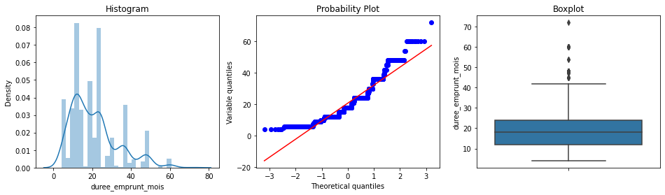

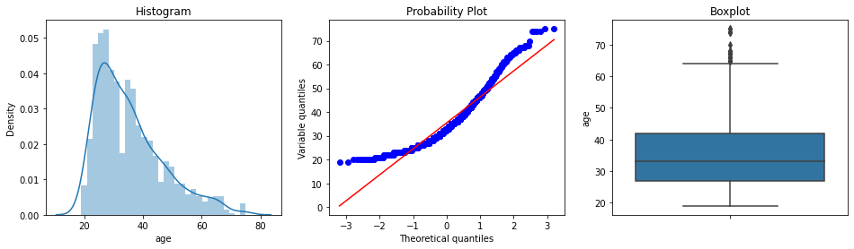

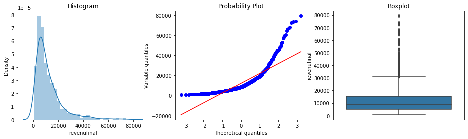

```python
for i in quantitatives :
    visu_plots(X, i)
```

Aucun retraitement n'est nécéssaire suite à cette partie " distribution des variables explicatives quantitatives".

### Analyse bivariée

Pour rappel :

```python
print(quantitatives)
```

```
['duree_emprunt_mois', 'age', 'revenufinal']
```

```python
print(qualitatives)
```

```
['annees_presence_logement', 'nbre_emprunts_actuels', 'compte_courant', 'historique_credit', 'raison', 'compte_epargne', 'duree_emploi', 'autre_credit', 'logement', 'job', 'dependants', 'defaillant']
```

Comportement des variables explicatives quantitatives par rapport à la target :

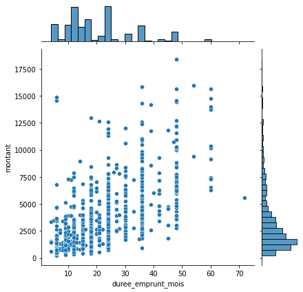

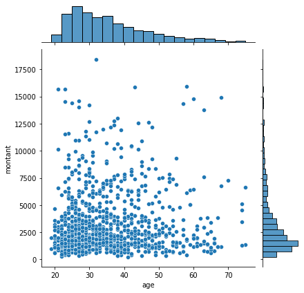

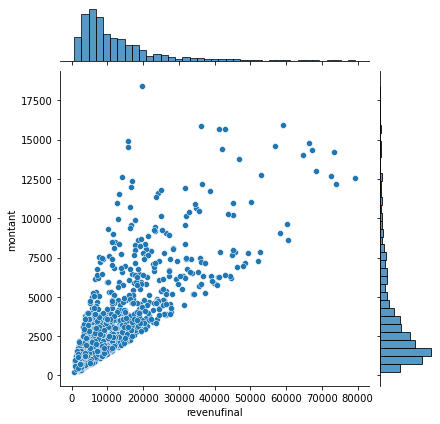

```python
for i in quantitatives :
    sns.jointplot(data = X, x = X[i], y = y)
    plt.show
```

Comportement des variables explicatives qualitatives par rapport à la target :

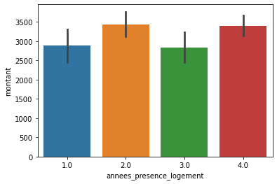

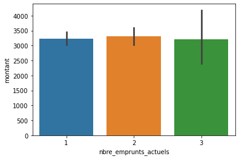

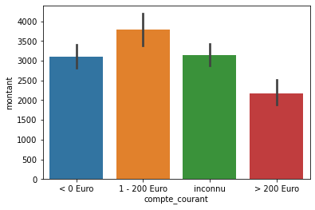

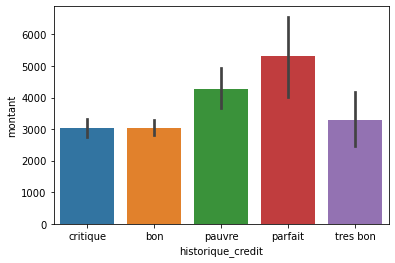

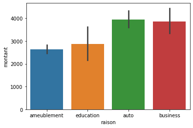

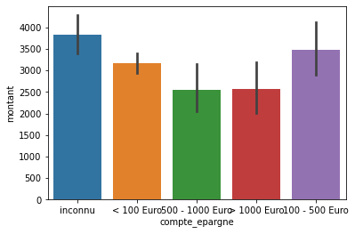

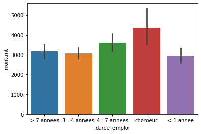

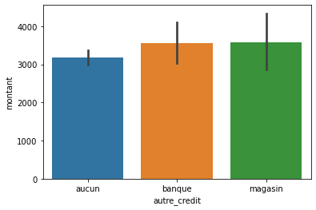

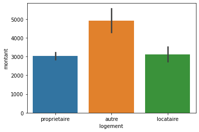

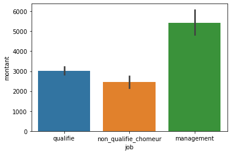

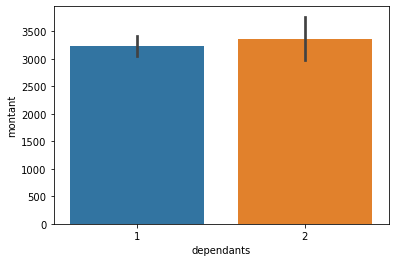

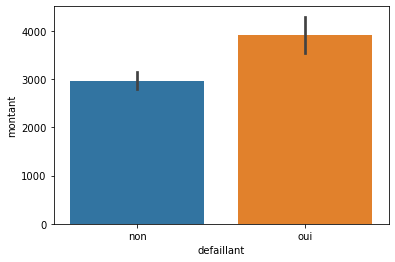

```python
for i in qualitatives :
    sns.barplot(X[i], y)
    plt.show()
```

### Analyse de correlation

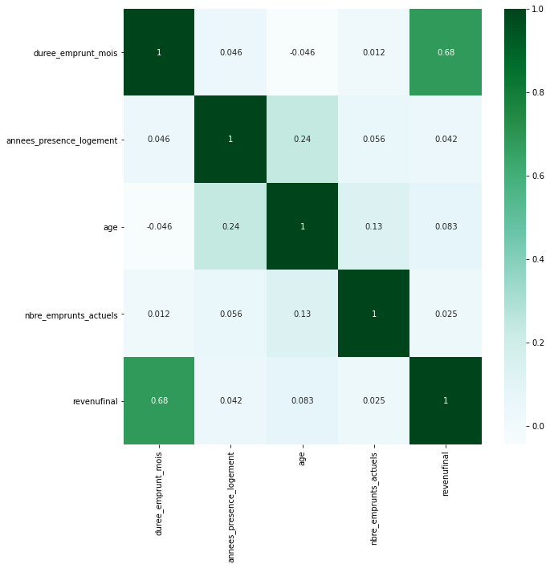

```python
correlations = X.corr(method='spearman')
#Nous preferons la corrélation au sens de Spearman car elle identifie les "corrélations monotones" (liens monotones entre les variables), en plus d'identifier les liens linéaires entre les variables.
f, ax = plt.subplots(figsize = (10, 10))
sns.heatmap(correlations, annot = True,cmap='BuGn')
```

Cette sortie nous permet d'identifier une forte corrélation entre les variables "revenufinal" et "duree_emprunt_mois".

Etudions maintenant la corrélation de ces variables avec la target

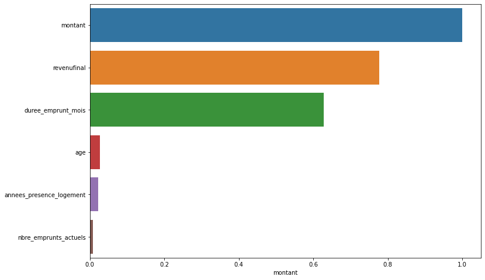

```python
df_corr = abs(pd.concat([X,y],axis=1).corr(method='spearman'))
corrmontant = df_corr.sort_values('montant',ascending=False)
plt.figure(figsize=(12, 8))
sns.barplot(x=corrmontant['montant'], y=corrmontant.index)
plt.show()
```

Puis la relation entre "duree_emprunt_mois" et "revenufinal" :

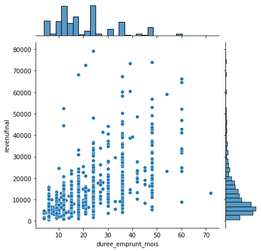

```python
sns.jointplot(data = X, x = X["duree_emprunt_mois"], y = X["revenufinal"])
```

Au vu de ces précédentes analyses nous pouvons identifier une corrélation claire entre la variable "revenufinal" et "duree_emprunt_mois". Suivant cela, nous conserverons uniquement la variable "revenufinal" qui est la plus corrélée à la cible des deux.

```python
X = X.drop(["duree_emprunt_mois"], axis=1)
```

```python
# Actualisation de la liste des variables quantitatives :
quantitatives.remove("duree_emprunt_mois")
```

## Préparation des données avant modélisation :

### Feature scaling

Afin de ne pas être confronté à des problèmes d'echelle lors de l'apprentissage nous allons implementer une procédure de remise à l'echelle de nos variable explicatives quantitatives :

```python
from sklearn import preprocessing
scaler = preprocessing.StandardScaler().fit(X[quantitatives])
X[quantitatives] = scaler.transform(X[quantitatives])
```

### Encodage des variables qualitatives et One Hot Encoding lorsque cela est nécessaire

Nous allons maintenant appliquer un one hot encoding aux variables qualitatives ne possédant pas de relation d'ordre entre les modalités afin que le modèle n'apprenne pas d'une quelconque relation d'ordre qui n'aurait pas lieu d'être :

```python
for i in qualitatives:
    print(X[i].unique())
```

```
[4. 2. 3. 1.]
[2 1 3]
['< 0 Euro' '1 - 200 Euro' 'inconnu' '> 200 Euro']
['critique' 'bon' 'pauvre' 'parfait' 'tres bon']
['ameublement' 'education' 'auto' 'business']
['inconnu' '< 100 Euro' '500 - 1000 Euro' '> 1000 Euro' '100 - 500 Euro']
['> 7 annees' '1 - 4 annees' '4 - 7 annees' 'chomeur' '< 1 annee']
['aucun' 'banque' 'magasin']
['proprietaire' 'autre' 'locataire']
['qualifie' 'non_qualifie_chomeur' 'management']
['1' '2']
['non' 'oui']
```

Cela concerne donc les variables suivantes :

```python
qualitatives_to_one_hot = ["compte_courant", "raison", "compte_epargne","autre_credit","logement","job"]
df_one_hot = X[qualitatives_to_one_hot].copy()
df_one_hot = pd.get_dummies(df_one_hot)
```

```python
X = X.drop(qualitatives_to_one_hot, axis=1)
X = pd.concat([X,df_one_hot],axis=1)
```

Ensuite, nous allons pouvoir encoder les variables qualitatives restantes en veillant à respecter l'ordre :

```python
X[["annees_presence_logement","nbre_emprunts_actuels"]] = X[["annees_presence_logement","nbre_emprunts_actuels"]].astype('int')
X["historique_credit"] = X["historique_credit"].replace(['critique', 'bon', 'pauvre', 'parfait', 'tres bon'],[0,2,1,4,3])
X["duree_emploi"] = X["duree_emploi"].replace(['> 7 annees', '1 - 4 annees', '4 - 7 annees', 'chomeur', '< 1 annee'],[4,2,3,0,1])
X["dependants"] = X["dependants"].astype('int')
X["defaillant"] = X["defaillant"].replace(['non', 'oui'],[0,1])
```

## Modélisation :

```python
from sklearn.preprocessing import scale
from sklearn.model_selection import train_test_split
from sklearn import linear_model
from sklearn.linear_model import Ridge, RidgeCV, Lasso, LassoCV
from sklearn.metrics import mean_squared_error
from sklearn.metrics import r2_score
```

### Découpage train/test set

```python
X_train, X_test, y_train, y_test = train_test_split(X, y, test_size= 0.3, random_state = 42)
```

### Régression linéaire classique

```python
# instance du modèle de régression linéaire
lr = linear_model.LinearRegression()

# entrainement sur le train data set
lr.fit(X_train,y_train)

# erreur mse sur le test data set comme base de comparaison
mse_test = mean_squared_error(y_test, lr.predict(X_test))
# sur le train data set
mse_train = mean_squared_error(y_train, lr.predict(X_train))

print("MSE train : ", mse_train, "\nEt donc le RMSE train : ", np.sqrt(mse_train))
print("MSE test : ", mse_test, "\nEt donc le RMSE test : ", np.sqrt(mse_test))
```

```
MSE train :  3039851.9271708685
Et donc le RMSE train :  1743.5171141032338
MSE test :  3159413.1791530945
Et donc le RMSE test :  1777.4738195408377
```

```python
print("Pour comparaison, la moyenne de la target 'montant' est : ", y.mean())
```

```
Pour comparaison, la moyenne de la target 'montant' est :  3250.088148873653
```

```python
print("Le R2 train est de : ", r2_score(y_train, lr.predict(X_train)), "\nEt le R2 de l'échantillon test est de : ", r2_score(y_test, lr.predict(X_test)))
```

```
Le R2 train est de :  0.6252795124002825
Et le R2 de l'échantillon test est de :  0.5921592260896328
```

```python
R2A_train = 1-(1-r2_score(y_train, lr.predict(X_train)))*(len(y_train)-1)/(len(y_train)-X_train.shape[1]-1)
R2A_test = 1-(1-r2_score(y_test, lr.predict(X_test)))*(len(y_test)-1)/(len(y_test)-X_test.shape[1]-1)
print("Le R2 ajusté train est de : ", R2A_train, "\nEt le R2 ajusté de l'échantillon test est de : ", R2A_test)
```

```
Le R2 ajusté train est de :  0.6088203401777473
Et le R2 ajusté de l'échantillon test est de :  0.5478287071863319
```

Nous avons donc, pour l'instant, des résultats plutôt corrects avec un leger sur-apprentissage sur l'échantillon test identifié par le calcul du R2-ajusté train/test.

### Régression régularisée Ridge

Tout d'abord il nous faut determiner le coefficient de régularisation optimal. Nous utiliserons pour cela une validation croisée k-fold. Mais d'abord, regardons l'impact de l'évolution du choix de cet hyper-paramètre sur :

- L’évolution des poids attribués aux variables explicatives
- Le MSE
- Le R2

```python
alphas = np.logspace(-5, 7, 300) # définition d'une plage de valeurs à tester
```

```python
ridge = linear_model.Ridge()

coefs = []
errors = []
errorstrain = []
r2 = []
r2train = []
for a in alphas:
    ridge.set_params(alpha=a)
    ridge.fit(X_train, y_train)
    coefs.append(ridge.coef_)
    mse_test = mean_squared_error(y_test, ridge.predict(X_test))
    errors.append(mse_test)
    mse_train = mean_squared_error(y_train, ridge.predict(X_train))
    errorstrain.append(mse_train)
    r2.append(r2_score(y_test, ridge.predict(X_test)))
    r2train.append(r2_score(y_train, ridge.predict(X_train)))
```

Affichage des poids de chaque variable explicative en fonction de alpha. Plus alpha augmente, plus les poids diminuent :

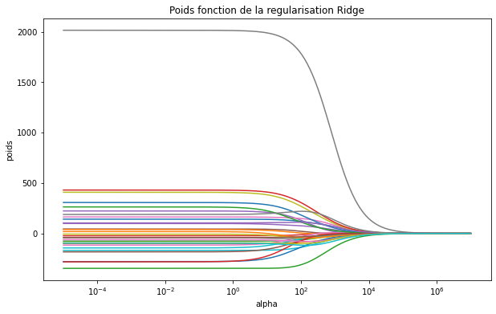

```python
# affichage evolution de la valeur des poids
plt.figure(figsize=(10,6))
ax = plt.gca()
ax.plot(alphas, coefs)
ax.set_xscale('log')
plt.xlabel('alpha')
plt.ylabel('poids')
plt.title('Poids fonction de la regularisation Ridge')
#plt.axis('tight')
plt.show()
```

Evolution de la MSE sur train/test :

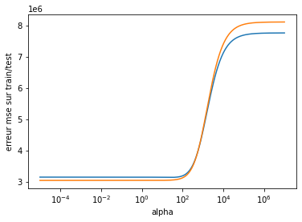

```python
ax = plt.gca()

ax.plot(alphas, errors)
ax.plot(alphas, errorstrain)
ax.set_xscale('log')
plt.xlabel('alpha')
plt.ylabel('erreur mse sur train/test')
plt.axis('tight')
plt.show()
```

Evolution du R2 sur train/test :

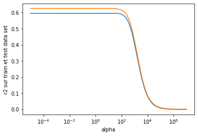

```python
ax = plt.gca()

ax.plot(alphas, r2)
ax.plot(alphas, r2train)
ax.set_xscale('log')
plt.xlabel('alpha')
plt.ylabel('r2 sur train et test data set')
plt.axis('tight')
plt.show()
```

#### Choix de l'hyper-paramètre par validation croisée 5-fold :

```python
ridgecv = RidgeCV(alphas = alphas,cv=5)
ridgecv.fit(X_train, y_train)
best_alpha = ridgecv.alpha_
print("Le meilleur alpha par cross-validation est : ", best_alpha)
```

```
Le meilleur alpha par cross-validation est :  45.94173134636476
```

#### Entrainement du modèle avec ce choix de alpha :

```python
ridge_final = Ridge(alpha = best_alpha)
ridge_final.fit(X_train, y_train)
mse_test = mean_squared_error(y_test, ridge_final.predict(X_test))
mse_train = mean_squared_error(y_train, ridge_final.predict(X_train))
print("MSE train : ", mse_train, "\nEt donc le RMSE train : ", np.sqrt(mse_train))
print("MSE test : ", mse_test, "\nEt donc le RMSE test : ", np.sqrt(mse_test))
```

```
MSE train :  3061398.3588779676
Et donc le RMSE train :  1749.6852170827665
MSE test :  3140048.051152129
Et donc le RMSE test :  1772.0180730320244
```

```python
print("Pour comparaison, la moyenne de la target 'montant' est : ", y.mean())
```

```
Pour comparaison, la moyenne de la target 'montant' est :  3250.088148873653
```

```python
print("Le R2 train est de : ", r2_score(y_train, ridge_final.predict(X_train)), "\nEt le R2 de l'échantillon test est de : ", r2_score(y_test, ridge_final.predict(X_test)))
```

```
Le R2 train est de :  0.6226234983611934
Et le R2 de l'échantillon test est de :  0.5946590222045885
```

```python
R2A_train = 1-(1-r2_score(y_train, ridge_final.predict(X_train)))*(len(y_train)-1)/(len(y_train)-X_train.shape[1]-1)
R2A_test = 1-(1-r2_score(y_test, ridge_final.predict(X_test)))*(len(y_test)-1)/(len(y_test)-X_test.shape[1]-1)
print("Le R2 ajusté train est de : ", R2A_train, "\nEt le R2 ajusté de l'échantillon test est de : ", R2A_test)
```

```
Le R2 ajusté train est de :  0.6060476637357699
Et le R2 ajusté de l'échantillon test est de :  0.5506002202703046
```

Nous obtenons quasiment les mêmes résultats que la régression simple plus haut. L'over-fitting s'est légèrement atténué grâce à la régularisation proposée par Ridge.

Pour information, voici les coefficients du modèle obtenu :

```python
pd.Series(ridge_final.coef_, index = X.columns)
```

```
historique_credit           130.299225
duree_emploi                -92.854699
annees_presence_logement    -70.263092
age                         -18.640319
nbre_emprunts_actuels       170.523206
                               ...
logement_locataire          -37.323944
logement_proprietaire       -73.164399
job_management              213.144860
job_non_qualifie_chomeur   -101.249241
job_qualifie               -111.895619
Length: 30, dtype: float64
```

## Lasso

Tout d'abord, il nous faut determiner la valeur optimale de l'hyper-paramètre. Nous utiliserons pour cela une validation croisée k-fold. Mais d'abord, regardons l'impact de l'évolution du choix de cet hyper-paramètre sur :

- L’évolution des poids attribués aux variables explicatives
- Le MSE
- Le R2

```python
alphas = np.logspace(-5, 6, 300) # définition d'une plage de valeurs à tester
```

```python
lasso = linear_model.Lasso()

coefs = []
errors = []
errorstrain = []
r2 = []
r2train = []
for a in alphas:
    lasso.set_params(alpha=a)
    lasso.fit(X_train, y_train)
    coefs.append(lasso.coef_)
    mse_test = mean_squared_error(y_test, lasso.predict(X_test))
    errors.append(mse_test)
    mse_train = mean_squared_error(y_train, lasso.predict(X_train))
    errorstrain.append(mse_train)
    r2.append(r2_score(y_test, lasso.predict(X_test)))
    r2train.append(r2_score(y_train, lasso.predict(X_train)))
```

Affichage des poids de chaque variable explicative en fonction de alpha. Plus alpha augmente, plus les poids diminuent :

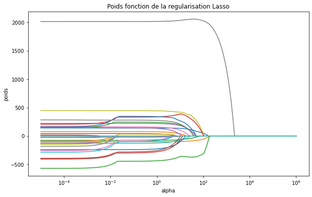

```python
# affichage evolution de la valeur des poids
plt.figure(figsize=(10,6))
ax = plt.gca()
ax.plot(alphas, coefs)
ax.set_xscale('log')
plt.xlabel('alpha')
plt.ylabel('poids')
plt.title('Poids fonction de la regularisation Lasso')
#plt.axis('tight')
plt.show()
```

Evolution de la MSE sur train/test :

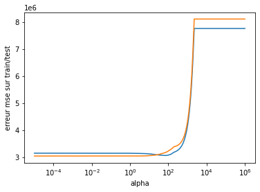

```python
ax = plt.gca()

ax.plot(alphas, errors)
ax.plot(alphas, errorstrain)
ax.set_xscale('log')
plt.xlabel('alpha')
plt.ylabel('erreur mse sur train/test')
plt.axis('tight')
plt.show()
```

Evolution du R2 sur train/test :

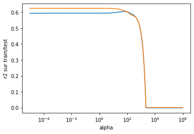

```python
ax = plt.gca()

ax.plot(alphas, r2)
ax.plot(alphas, r2train)
ax.set_xscale('log')
plt.xlabel('alpha')
plt.ylabel('r2 sur train/test')
plt.axis('tight')
plt.show()
```

#### Choix de l'hyper-paramètre par validation croisée 5-fold :

```python
lassocv = LassoCV(alphas = alphas,random_state=42,cv=5)
lassocv.fit(X_train, y_train)
best_alpha = lassocv.alpha_
print("Le meilleur alpha par cross-validation est : ", best_alpha)
```

```
Le meilleur alpha par cross-validation est :  54.00593278542374
```

#### Entrainement du modèle avec ce choix de alpha :

```python
lasso_final = Lasso(alpha = best_alpha)
lasso_final.fit(X_train, y_train)
mse_test = mean_squared_error(y_test, lasso_final.predict(X_test))
mse_train = mean_squared_error(y_train, lasso_final.predict(X_train))
print("MSE train : ", mse_train, "\nEt donc le RMSE train : ", np.sqrt(mse_train))
print("MSE test : ", mse_test, "\nEt donc le RMSE test : ", np.sqrt(mse_test))
```

```
MSE train :  3144180.4916763967
Et donc le RMSE train :  1773.1837162788283
MSE test :  3063069.4583658203
Et donc le RMSE test :  1750.1626948274895
```

```python
print("Pour comparaison, la moyenne de la target 'montant' est : ", y.mean())
```

```
Pour comparaison, la moyenne de la target 'montant' est :  3250.088148873653
```

```python
print("Le R2 train est de : ", r2_score(y_train, lasso_final.predict(X_train)), "\nEt le R2 de l'échantillon test est de : ", r2_score(y_test, lasso_final.predict(X_test)))
```

```
Le R2 train est de :  0.612419000935017
Et le R2 de l'échantillon test est de :  0.6045959969135801
```

```python
R2A_train = 1-(1-r2_score(y_train, lasso_final.predict(X_train)))*(len(y_train)-1)/(len(y_train)-X_train.shape[1]-1)
R2A_test = 1-(1-r2_score(y_test, lasso_final.predict(X_test)))*(len(y_test)-1)/(len(y_test)-X_test.shape[1]-1)
print("Le R2 ajusté train est de : ", R2A_train, "\nEt le R2 ajusté de l'échantillon test est de : ", R2A_test)
```

```
Le R2 ajusté train est de :  0.5953949453391905
Et le R2 ajusté de l'échantillon test est de :  0.5616173009259258
```

Nous obtenons quasiment les mêmes résultats que la régression simple et Ridge plus haut. L'over-fitting s'est légèrement atténué grâce à la "régularisation + sélection de variables" proposée par Lasso.

Pour information, voici les coefficients du modèle obtenu :

```python
pd.Series(lasso_final.coef_, index = X.columns)
```

```
historique_credit           79.339647
duree_emploi               -74.800849
annees_presence_logement   -14.783462
age                         -0.000000
nbre_emprunts_actuels        0.000000
                              ...
logement_locataire          -0.000000
logement_proprietaire       -0.000000
job_management               0.000000
job_non_qualifie_chomeur    -0.000000
job_qualifie                -0.000000
Length: 30, dtype: float64
```

Et les variables explicatives retirées du modèle par Lasso sont :

```python
pd.Series(lasso_final.coef_[lasso_final.coef_ == 0], index = X.columns[lasso_final.coef_ == 0])
```

```
age                              -0.0
nbre_emprunts_actuels             0.0
dependants                        0.0
defaillant                        0.0
compte_courant_< 0 Euro          -0.0
compte_courant_> 200 Euro        -0.0
compte_courant_inconnu            0.0
raison_business                   0.0
raison_education                 -0.0
compte_epargne_100 - 500 Euro    -0.0
compte_epargne_500 - 1000 Euro   -0.0
compte_epargne_< 100 Euro        -0.0
compte_epargne_> 1000 Euro       -0.0
compte_epargne_inconnu            0.0
autre_credit_aucun               -0.0
autre_credit_banque               0.0
autre_credit_magasin             -0.0
logement_autre                    0.0
logement_locataire               -0.0
logement_proprietaire            -0.0
job_management                    0.0
job_non_qualifie_chomeur         -0.0
job_qualifie                     -0.0
dtype: float64
```

Feature importance au sens de Lasso :

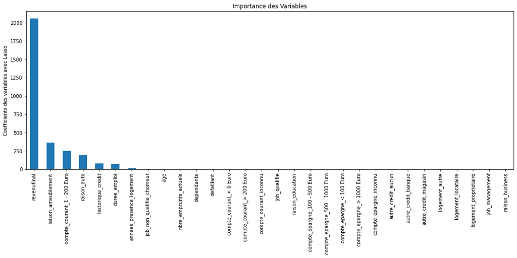

```python
importance = pd.Series(np.abs(lasso_final.coef_.ravel()))
importance.index = X.columns
importance.sort_values(inplace=True, ascending=False)
importance.plot.bar(figsize=(18,6))
plt.ylabel('Coefficients des variables avec Lasso')
plt.title('Importance des Variables')
```

## ElasticNet

Commençons par observer le R2 du modèle avec le choix par défaut des hyper-paramètres :

```python
from sklearn.linear_model import ElasticNet

Elastic_Net = ElasticNet()
Elastic_Net.fit(X_train, y_train)

print("Le R2 train est de : ", r2_score(y_train, Elastic_Net.predict(X_train)), "\nEt le R2 de l'échantillon test est de : ", r2_score(y_test, Elastic_Net.predict(X_test)))
```

```
Le R2 train est de :  0.5591614481515754
Et le R2 de l'échantillon test est de :  0.5349144494211553
```

Ce qui est donc peu par rapport aux résultats observés précedemment. Penchons nous alors sur le choix des deux hyper-paramètres par validation croisée 5-fold :

```python
# Pour information, ce bloc met un peu de temps à tourner (environ 5 minutes) : output = {'alpha': 5, 'l1_ratio': 0.99}

from sklearn.model_selection import GridSearchCV
from sklearn.model_selection import RepeatedKFold

Elastic_Net_final = ElasticNet()

cv = RepeatedKFold(n_splits=5, random_state=42)

# definition de la grille de recherche
grid = dict()
grid['alpha'] = [1e-5, 1e-4, 1e-3, 1e-2, 0.02, 0.05, 0.08, 0.1, 0.2, 0.5, 0.8, 1, 5, 10, 20, 50, 80, 100]
grid['l1_ratio'] = np.arange(0, 1, 0.01)

# Recherche
search = GridSearchCV(Elastic_Net_final, grid, scoring='neg_mean_absolute_error', cv=cv)
results = search.fit(X_train, y_train)

print("Les meilleurs hyper-paramètres après cross-validation sont : ", results.best_params_)
```

```
Les meilleurs hyper-paramètres après cross-validation sont :  {'alpha': 5, 'l1_ratio': 0.99}
```

Entrainement du modèle avec ce choix d'hyper-paramètres :

```python
Elastic_Net_final = ElasticNet(alpha=5, l1_ratio=0.99)
Elastic_Net_final.fit(X_train, y_train)

print("Le R2 train est de : ", r2_score(y_train, Elastic_Net_final.predict(X_train)), "\nEt le R2 de l'échantillon test est de : ", r2_score(y_test, Elastic_Net_final.predict(X_test)))
```

```
Le R2 train est de :  0.6227005451712975
Et le R2 de l'échantillon test est de :  0.5961025972713497
```

```python
R2A_train = 1-(1-r2_score(y_train, Elastic_Net_final.predict(X_train)))*(len(y_train)-1)/(len(y_train)-X_train.shape[1]-1)
R2A_test = 1-(1-r2_score(y_test, Elastic_Net_final.predict(X_test)))*(len(y_test)-1)/(len(y_test)-X_test.shape[1]-1)
print("Le R2 ajusté train est de : ", R2A_train, "\nEt le R2 ajusté de l'échantillon test est de : ", R2A_test)
```

```
Le R2 ajusté train est de :  0.6061280947395828
Et le R2 ajusté de l'échantillon test est de :  0.5522007056704095
```

### Sélection des variables par récursivité

```python
from sklearn.linear_model import LinearRegression
from sklearn.pipeline import Pipeline
from sklearn.model_selection import RepeatedStratifiedKFold
from sklearn.feature_selection import RFE
import numpy as np
from sklearn.model_selection import cross_val_score
```

Au vu du grpahique de la partie "Feature importance au sens de Lasso", nous allons selectionner 6 variables :

```python
rfe = RFE(estimator=LinearRegression(), n_features_to_select=6)
rfe.fit(X_train, y_train)
```

```
RFE(estimator=LinearRegression(), n_features_to_select=6)
```

```python
# variables retenus ou supprimés
variables_retenues = X.columns[rfe.support_]
variables_retenues
```

```
Index(['revenufinal', 'compte_courant_1 - 200 Euro', 'raison_ameublement',
       'raison_education', 'autre_credit_banque', 'job_management'],
      dtype='object')
```

Il est intéressant de remarquer que le choix des variables retenues n'est pas exactement le même que celui de la selection de variables induite par Lasso.

```python
#Entrainement du modèle avec ces variables et performance :

lr_final = linear_model.LinearRegression()
lr_final.fit(X_train[variables_retenues],y_train)

print("Le R2 train est de : ", r2_score(y_train, lr_final.predict(X_train[variables_retenues])), "\nEt le R2 de l'échantillon test est de : ", r2_score(y_test, lr_final.predict(X_test[variables_retenues])))
```

```
Le R2 train est de :  0.6150356516873953
Et le R2 de l'échantillon test est de :  0.5926662819975144
```

```python
mse_test = mean_squared_error(y_test, lr_final.predict(X_test[variables_retenues]))
mse_train = mean_squared_error(y_train, lr_final.predict(X_train[variables_retenues]))

print("MSE train : ", mse_train, "\nEt donc le RMSE train : ", np.sqrt(mse_train))
print("MSE test : ", mse_test, "\nEt donc le RMSE test : ", np.sqrt(mse_test))
```

```
MSE train :  3122953.387486548
Et donc le RMSE train :  1767.1879887229168
MSE test :  3155485.1777848927
Et donc le RMSE test :  1776.3685365894355
```

```python
print("Pour comparaison, la moyenne de la target 'montant' est : ", y.mean())
```

```
Pour comparaison, la moyenne de la target 'montant' est :  3250.088148873653
```

```python
R2A_train = 1-(1-r2_score(y_train, lr_final.predict(X_train[variables_retenues])))*(len(y_train)-1)/(len(y_train)-X_train[variables_retenues].shape[1]-1)
R2A_test = 1-(1-r2_score(y_test, lr_final.predict(X_test[variables_retenues])))*(len(y_test)-1)/(len(y_test)-X_test[variables_retenues].shape[1]-1)
print("Le R2 ajusté train est de : ", R2A_train, "\nEt le R2 ajusté de l'échantillon test est de : ", R2A_test)
```

```
Le R2 ajusté train est de :  0.611768627515011
Et le R2 ajusté de l'échantillon test est de :  0.5845196076374646
```

#### Analyse complémentaire

Il est possible d'observer l'évolution de la performance du modèle au cours de cette procédure de sélection :

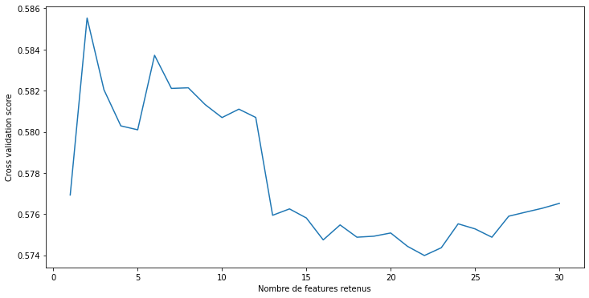

```python
from sklearn.feature_selection import RFECV

rfecv = RFECV(estimator=LinearRegression())
model = LinearRegression()
pipeline = Pipeline([('Feature Selection', rfecv), ('Model', model)])
cv = RepeatedStratifiedKFold(n_splits=5, random_state=42)

pipeline.fit(X_train,y_train)


# visu du score en fonction du nbre de features retenus
import matplotlib.pyplot as plt
plt.figure(figsize=(12,6))
plt.xlabel("Nombre de features retenus")
plt.ylabel("Cross validation score")
plt.plot(range(1, len(rfecv.grid_scores_) + 1), rfecv.grid_scores_)
plt.show()
```

```python
print("Nous remarquons que le nombre de variables explicatives optimal peut encore être diminué pour atteindre ", rfecv.n_features_)
```

```
Nous remarquons que le nombre de variables explicatives optimal peut encore être diminué pour atteindre  2
```

```python
print("Ces variables sont : ", X.columns[rfecv.support_])
```

```
Ces variables sont :  Index(['revenufinal', 'raison_ameublement'], dtype='object')
```

```python
variables_retenues = ['revenufinal', 'raison_ameublement']

lr_rfecv = linear_model.LinearRegression()
lr_rfecv.fit(X_train[variables_retenues],y_train)

print("Le R2 train est de : ", r2_score(y_train, lr_rfecv.predict(X_train[variables_retenues])), "\nEt le R2 de l'échantillon test est de : ", r2_score(y_test, lr_rfecv.predict(X_test[variables_retenues])))
```

```
Le R2 train est de :  0.6031757065537205
Et le R2 de l'échantillon test est de :  0.5993821879262057
```

```python
mse_test = mean_squared_error(y_test, lr_rfecv.predict(X_test[variables_retenues]))
mse_train = mean_squared_error(y_train, lr_rfecv.predict(X_train[variables_retenues]))

print("MSE train : ", mse_train, "\nEt donc le RMSE train : ", np.sqrt(mse_train))
print("MSE test : ", mse_test, "\nEt donc le RMSE test : ", np.sqrt(mse_test))
```

```
MSE train :  3219165.0392744634
Et donc le RMSE train :  1794.2031766983537
MSE test :  3103459.183675429
Et donc le RMSE test :  1761.6637544308587
```

```python
print("Pour comparaison, la moyenne de la target 'montant' est : ", y.mean())
```

```
Pour comparaison, la moyenne de la target 'montant' est :  3250.088148873653
```

```python
R2A_train = 1-(1-r2_score(y_train, lr_rfecv.predict(X_train[variables_retenues])))*(len(y_train)-1)/(len(y_train)-X_train[variables_retenues].shape[1]-1)
R2A_test = 1-(1-r2_score(y_test, lr_rfecv.predict(X_test[variables_retenues])))*(len(y_test)-1)/(len(y_test)-X_test[variables_retenues].shape[1]-1)
print("Le R2 ajusté train est de : ", R2A_train, "\nEt le R2 ajusté de l'échantillon test est de : ", R2A_test)
```

```
Le R2 ajusté train est de :  0.602059463815475
Et le R2 ajusté de l'échantillon test est de :  0.5967465444257203
```

Qui aboutit à un modèle avec un meilleur pouvoir de généralisation que le précédent mais dont les performances sur l'échantillon d'apprentissage sont moindres.

## Validation du modèle de régression :

Nous ferrons cette étude avec le modèle "lr_final" obtenu après selection de variables par récursivité :

```python
variables_retenues  = X.columns[rfe.support_]
```

- Les erreurs sont centrés

```python
erreurs = y_test - lr_final.predict(X_test[variables_retenues])
```

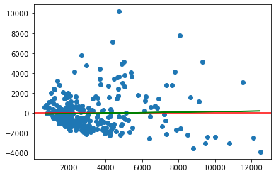

```python
plt.scatter(lr_final.predict(X_test[variables_retenues]), erreurs)
plt.axhline(y=0, color='r', linestyle='-')

x_plot = lr_final.predict(X_test[variables_retenues])
y_plot = erreurs
slope, intercept = np.polyfit(x_plot, y_plot, 1)
plt.plot(x_plot, slope*x_plot + intercept, color='g')

plt.show()
```

```python
print("La moyenne des erreurs est : ", np.mean(erreurs))
```

```
La moyenne des erreurs est :  -30.345667177277026
```

Les erreurs sont donc relativement centrées.

- Les erreurs sont non corrélées

Pour cela nous allons utiliser le test de Durbin Watson :

```python
from statsmodels.stats.stattools import durbin_watson

durbin_watson(erreurs)
```

```
1.9405430866252802
```

Les erreurs sont donc non corrélées puisque la statistique de Durbin-Watson est proche de 2 (relativement à une échelle de variation de cette dernière entre 0 et 4)

- Les erreurs sont de variance constante

Pour cela nous utiliserons le test de Breusch-Pagan de la librairie statsmodels.

```python
X = X.rename(columns={"compte_courant_1 - 200 Euro": "compte_courant_1_200_Euro"})
variables_retenues = list(variables_retenues)
variables_retenues.remove("compte_courant_1 - 200 Euro")
variables_retenues.append("compte_courant_1_200_Euro")
#afin d'avoir un format compatible à ce que demande la librairie
```

```python
import statsmodels.formula.api as smf
import statsmodels.stats.api as sms
from statsmodels.compat import lzip

names = ['Lagrange multiplier statistic', 'p-value']

fit = smf.ols('montant ~ revenufinal + compte_courant_1_200_Euro + raison_ameublement + raison_education + autre_credit_banque + job_management', data=pd.concat([X[variables_retenues],y], axis = 1)).fit()
test = sms.het_breuschpagan(fit.resid, fit.model.exog)

lzip(names, test)
```

```
[('Lagrange multiplier statistic', 74.15760521828157),
 ('p-value', 5.721588419998139e-14)]
```

Ainsi, nous rejetons l'hypothèse d'homoscédasticité.

- Les erreurs sont gaussiennes

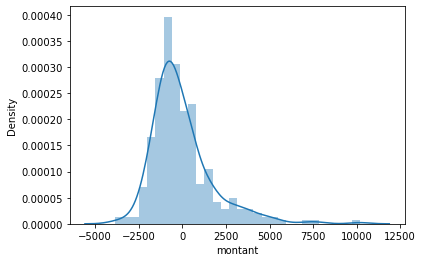

```python
sns.distplot(erreurs)
plt.show()
```

A première vue ça n'a pas l'air d'être le cas, confirmons cela avec le test de Shapiro :

```python
from scipy.stats import shapiro
shapiro(erreurs)
```

```
ShapiroResult(statistic=0.8690114617347717, pvalue=1.7628230528481397e-15)
```

Le test de Shapiro rejette clairement l'hypothèse de normalité des résidus. Nous pouvons obtenir une illustration de cela au travers de la sortie ci-dessous :

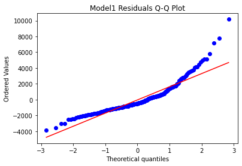

```python
stats.probplot(erreurs, dist="norm", plot= plt)
plt.title("Model1 Residuals Q-Q Plot")
```

## Conclusion

Nos données ne sont pas adaptées à une modélisation de type "Regression linéaire" au vu de la partie "Validation du modèle" (les deux derniers postulats ne sont pas vérifiés). Ceci explique les performances limitées de notre modèle final. Pour résoudre cela il est possible de :

- Ajouter de nouvelles variables explicatives au modèle
- Tester des croisements entre les variables explicatives
- Appliquer des transformations aux varibles explicatives / à la target afin de créer une relation linéaire.
- Réfléchir à une approche non linéaire (exemple : Random Forest par exemple)

Ces 4 points seraient à explorer pour une approche "complète". Cependant, ils sortent du cadre de ce projet et de ce qui est attendu, c'est pourquoi nous les laisseront à l'état de points ouverts. Au vu de leur importance il est nécéssaire de les citer ici afin de les garder à l'esprit.

Ceci conclut ce travail. Je vous remercie de l'attention portée à ce dernier.